# Statistics Homework 01

B08705034 資管一 施芊羽

## Chapter 1

### 1.3

#### a.

The population of interest is $25,000$ which are the number of the registered voters in the city.

#### b.

The sample is $200$ which is the number of registered voters who are interviewed.

#### c.

$48\%$ is a statistic since it's a description of the sample instead of the population.

### 1.7

#### a.

I'll make the conclusion that the percentage of observed a head is $95\%$ is far from fair($50-50$ in this case). However, I'll state that my conclusion and opinion will be a bit wrong since the sample is not large enough.

#### b.

I'll conclude that the owner is quite true since after my flips I got a $55\%$ chance to observe head which may be closed to $50\%$, and it might be closer when the sample is larger.

#### c.

No, I don't believe that if I flip a perfectly fair coin $100$ times, I will always observe exactly $50$ heads. I do think that the number between $40 - 60$ may be likely got, however, the numbers from $0$ to $100$ are all possible to happen.

## Chapter 2

### 2.5

#### a.

Interval.

#### b.

Interval.

#### c.

Nominal.

#### d.

Interval.

#### e.

Nominal.

### 2.11

#### a.

Nominal.

#### b.

Interval.

#### c.

Ordinal.

### 2.13

|  | Country | Oil Reserves (Barrels) |
| --- | --- | --- |
| 14 | Venezuela | 298400000000 |
| 11 | Saudi Arabia | 268300000000 |
| 1 | Canada | 172500000000 |
| 3 | Iran | 157800000000 |
| 4 | Iraq | 144200000000 |
| 6 | Kuwait | 104000000000 |
| 10 | Russia | 103200000000 |
| 12 | United Arab Emirates | 97800000000 |
| 7 | Libya | 48360000000 |
| 8 | Nigeria | 37070000000 |
| 13 | United States | 36520000000 |
| 5 | Kazakhstan | 30000000000 |
| 9 | Qatar | 25240000000 |
| 2 | China | 24650000000 |
| 0 | Brazil | 15310000000 |

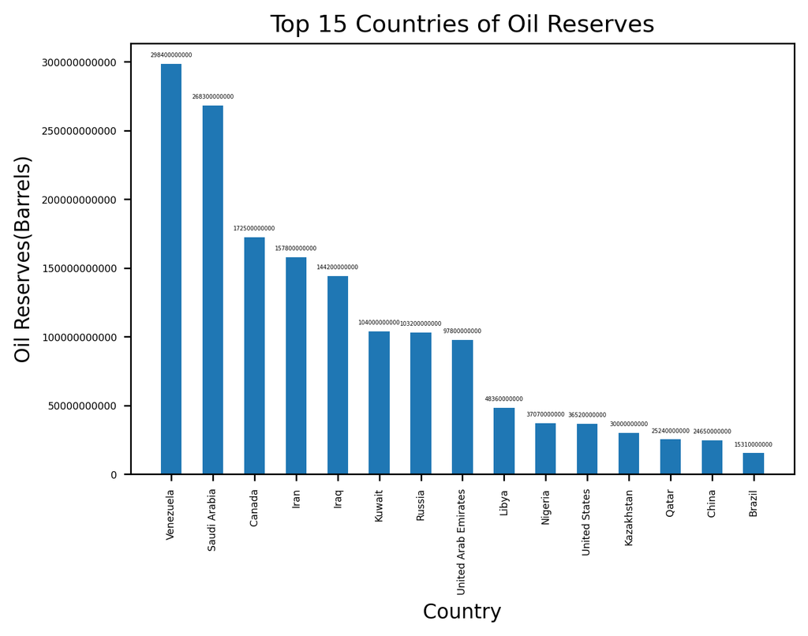

```python
from matplotlib import pyplot as plt
%matplotlib inline
# 設定圖形大小; DPI越大圖越大
plt.rcParams["figure.dpi"] = 250
import seaborn as sns
import pandas as pd
import numpy as np
import scipy.stats as stats
import statsmodels.api as sm
import statsmodels.stats.api as sms
import statsmodels.formula.api as smf

df_c02_13 = pd.read_excel('Xr02-13.xlsx') # Read the given data
df_c02_13 = df_c02_13.sort_values(by=['Oil Reserves (Barrels)'], ascending = False) # Sorting the data with a descending order
display(df_c02_13)
sizes = df_c02_13['Oil Reserves (Barrels)'] # Collect the data of each country
labels =  df_c02_13['Country']

fig, ax = plt.subplots()
rects1 = ax.bar(labels, sizes, width=0.5, bottom=None, align='center')
plt.ylabel('Oil Reserves(Barrels)')
plt.yticks(np.arange(0, 350000000000, 50000000000),np.arange(0, 350000000000, 50000000000), fontsize=5) # set the y-axis display
plt.title('Top 15 Countries of Oil Reserves')
plt.xlabel('Country')
plt.xticks(labels, rotation = 90, fontsize = 5) # Rotate the labels display to make it more clear

def autolabel(rects):
    """Attach a text label above each bar in *rects*, displaying its height."""
    for rect in rects:
        height = rect.get_height()
        plt.annotate('{}'.format(height),
                    xy=(rect.get_x() + rect.get_width() / 2, height),
                    xytext=(0, 3),  # 3 points vertical offset
                    textcoords="offset points",
                    ha='center', va='bottom', fontsize = 2.8)

autolabel(rects1)

plt.show()
```

#### Results:

I applied the code provided in Professor Chen's slides and made a few change to make the display clear and readible. From the graph, we can see the rank of the top 15 countries of oil reserves, but we still need further data to predict about when the world will run out of oil.

### 2.29

#### a.

```python
df_c02_29 = pd.read_excel('Xr02-29.xlsx')

counts = df_c02_29['Newspaper'].value_counts()
display(counts, counts/ counts.sum())
```

```
1    141
2    128
4     59
3     32
Name: Newspaper, dtype: int64
```

```
1    0.391667
2    0.355556
4    0.163889
3    0.088889
Name: Newspaper, dtype: float64
```

#### Result:

| No. | Newspapers | Frequency Distribution | Proportion |
| --- | --- | --- | --- |
| 1 | New York Daily News | $141$ | $39.17\%$ |
| 2 | New York Post | $128$ | $35.56\%$ |
| 3 | New York Times | $32$ | $8.89\%$ |
| 4 | Wall Street Journal | $59$ | $16.39\%$ |

#### b.

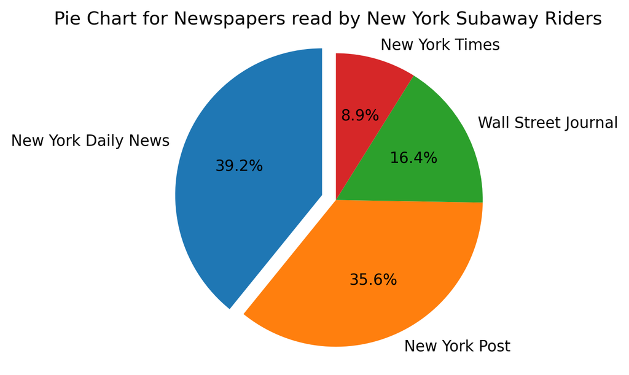

```python
Newspapers = ("New York Daily News", "New York Post", "Wall Street Journal", "New York Times")
explode = (0.1, 0, 0, 0)  # only "explode" the 1st slice (i.e. 'Budweiser Light')
fig2, ax2 = plt.subplots()
ax2.pie(counts, explode=explode, labels=Newspapers, autopct='%1.1f%%',
        shadow=False, startangle=90)
ax2.axis('equal')  # Equal aspect ratio ensures that pie is drawn as a circle.
plt.title('Pie Chart for Newspapers read by New York Subaway Riders')
plt.show()
```

#### Result:

From the graph we can know that New York Daily takes the largest part read by the subway riders in New York, with a $39.2\%$ of all riders that took the survey. The second is New York Post with $35.6\%$ and the third is Wall Street Journal with $16.4\%$. The least one is New York Times

### 2.41

|  | Education | 2000 | 2005 | 2010 | 2015 |
| --- | --- | --- | --- | --- | --- |
| 0 | Less than high school | 27854 | 28017 | 25711 | 24582 |
| 1 | High school | 58086 | 60893 | 62456 | 62575 |
| 2 | Some college | 44445 | 48076 | 53920 | 56031 |
| 3 | College graduate | 44845 | 52381 | 59840 | 68945 |

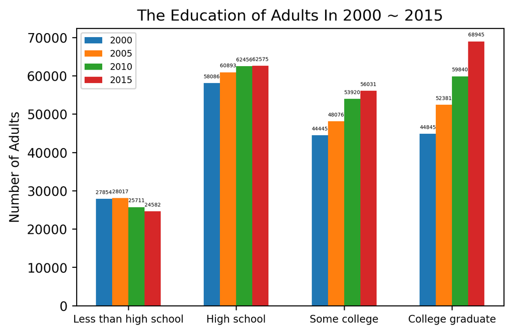

```python
#讀取資料集
df_c02_41 = pd.read_excel('Xr02-41.xlsx')

display(df_c02_41)

def autolabel(rects):
    """Attach a text label above each bar in *rects*, displaying its height."""
    for rect in rects:
        height = rect.get_height()
        ax.annotate('{}'.format(height),
                    xy=(rect.get_x() + rect.get_width() / 2, height),
                    xytext=(0, 3),  # 3 points vertical offset
                    textcoords="offset points",
                    ha='center', va='bottom', fontsize=4)

Education = ("Less than high school", "High school", "Some college", "College graduate")
Year = ("2000", "2005", "2010", "2015")
x = np.arange(len(Education))  # the label locations
width = 0.15  # the width of the bars
fig, ax = plt.subplots()
rects1 = ax.bar(x - 3*width/2, df_c02_41[2000], width, label = "2000")
rects2 = ax.bar(x - width/2, df_c02_41[2005], width, label = "2005")
rects3 = ax.bar(x + width/2, df_c02_41[2010], width, label = "2010")
rects4 = ax.bar(x + 3*width/2, df_c02_41[2015], width, label = "2015")
# Add some text for labels, title and custom x-axis tick labels, etc.
ax.set_ylabel('Number of Adults', fontsize=10)
ax.set_title('The Education of Adults In 2000 ~ 2015')
ax.set_xticks(x)
ax.set_xticklabels(Education, fontsize=8)
ax.legend(fontsize=7)
autolabel(rects1)
autolabel(rects2)
autolabel(rects3)
autolabel(rects4)
plt.show()
```

#### Result:

From the graph, we can know that adults that have an education higher than high school kept growing since 2000. And those with college graduate had a dramatic growth from 2010 to 2015. On the other hand, the number of adults with education less than high school had been decreasing since 2005. Last but not least, before 2015, the number of adults with high school education was higher than that with college graduate, but in 2015 the number of adults with college graduate became greater than the number of adults with high school education.

### 2.51

```
Contingency Table:
```

| Share Political View | 1 | 2 | 3 | 4 |
| --- | --- | --- | --- | --- |
| 1 | 122 | 81 | 187 | 18 |
| 2 | 70 | 39 | 236 | 7 |
| 3 | 34 | 41 | 259 | 7 |

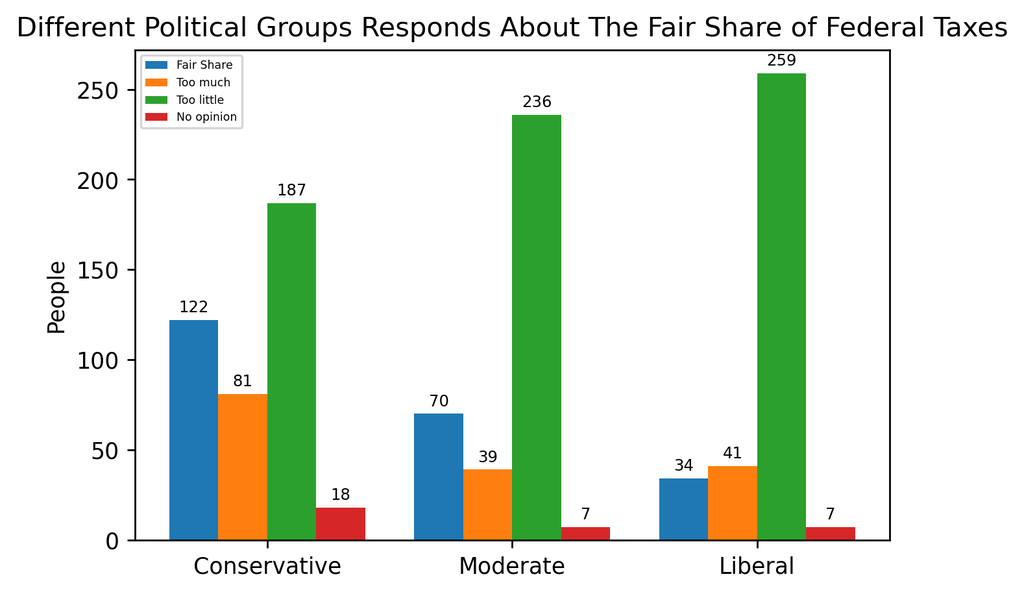

```python
#讀取資料集
df_c02_51 = pd.read_excel('Xr02-35.xlsx')

# 列出Contingency Table
contb = pd.crosstab(df_c02_51["Political View"], df_c02_51["Share"])
print("Contingency Table:")
display(contb)

def autolabel(rects):
    """Attach a text label above each bar in *rects*, displaying its height."""
    for rect in rects:
        height = rect.get_height()
        ax.annotate('{}'.format(height),
                    xy=(rect.get_x() + rect.get_width() / 2, height),
                    xytext=(0, 2),  # 3 points vertical offset
                    textcoords="offset points",
                    ha='center', va='bottom', fontsize = 7)

Share = ("Fair Share", "Too much", "Too little", "No opinion")
PV = ("Conservative", "Moderate", "Liberal")
x = np.arange(len(PV))  # the label locations
width = 0.2  # the width of the bars
fig, ax = plt.subplots()
rects1 = ax.bar(x - 3*width/2, contb[1], width, label = "Fair Share")
rects2 = ax.bar(x - width/2, contb[2], width, label = "Too much")
rects3 = ax.bar(x + width/2, contb[3], width, label =  "Too little")
rects4 = ax.bar(x + 3*width/2, contb[4], width, label = "No opinion")
# Add some text for labels, title and custom x-axis tick labels, etc.
ax.set_ylabel('People')
ax.set_title('Different Political Groups Responds About The Fair Share of Federal Taxes')
ax.set_xticks(x)
ax.set_xticklabels(PV)
ax.legend(fontsize = 5, loc = 0)
autolabel(rects1)
autolabel(rects2)
autolabel(rects3)
autolabel(rects4)
plt.show()
```

#### Result:

From the graph, we can know that in all political groups, most people think that the higher-income class pay too little on the fair share of federal taxes. However, in the conservative group there are also a high percentage of people think the share is fair or too much; in liberal group, a huge number of people do think it's too little; in moderate group, more people think the share is fair than those in liberal but still less than the conservative group.